# Why, When and How to Adjust Your P-Values?

Ojan Khosravifar

# Mutliple Testing

This document was developed and adapted in part from [Jafari & Ansari-Pour (2019)](https://doi.org/10.22074/cellj.2019.5992). Adjusting p-values for multiple testing is an important part of analyzing ’omics data. For example, suppose you want to independently test the transcriptional expression of twenty genes across two experiments. At first blush this doesn’t seem like a bad idea. However, using a significance level, or alpha (*α*), of 0.05, what’s the probability of observing at least one significant result due to chance alone?

**ℙ**(at least one significant result) = 1 - **ℙ**(no significant results)

⠀⠀⠀⠀⠀⠀⠀⠀⠀⠀⠀⠀⠀= 1 - (1 - 0.05)<sup>20</sup>

⠀⠀⠀⠀⠀⠀≈ 0.64

So, with 20 tests being considered, we have a 64% chance of observing at least one significant result, even if all of the tests are not actually significant. In the ’omics, it is common for the number of tests to be well above 20, quickly making individual hypothesis testing problematic. By adjusting our p-values in cases of multiple independent tests we can avoid the possibility of observing a false positive.

The two most popular strategies of p-value adjustment are the Bonferroni and [Benjamini-Hochberg](https://doi.org/10.1111/j.2517-6161.1995.tb02031.x) method.

### The Bonferroni Method

The Bonferroni method sets the significance cut-off at *α*/*n*, where *n* is the number of tests performed. For example, with 20 tests and *α* = 0.05, you’d only reject a null hypothesis if the p-value is less than 0.05/20 = 0.0025.

The Bonferroni method tends to be a bit too conservative. To demonstrate this, let’s calculate the probability of observing at least one significant result when using the correction just described:

**ℙ**(at least one significant result) = 1 - **ℙ**(no significant results)

⠀⠀⠀⠀⠀⠀⠀⠀⠀⠀⠀⠀⠀⠀⠀= 1 - (1 - 0.0025)<sup>20</sup>

⠀⠀⠀⠀⠀⠀⠀⠀≈ 0.0488

Here, we’re just a shade under our desired 0.05 level. However, we’re assuming that all tests are independent of each other. Practically, that is often not the case and the Bonferroni correction can be extremely conservative, leading to a high rate of false negatives.

Let’s use an example data set of 1300 hypothetical p-values between 0-1.0 to demonstrate this.

```r
#generate data set of p-values from 0-1.0
#first beta function is highly positively skewed
#second beta function is highly negatively skewed but less numerous
no.adj <- sort(c(rbeta(1000,.5,5),rbeta(300,5,2)))

#summary statistics
summary(no.adj)
```

```
##      Min.   1st Qu.    Median      Mean   3rd Qu.      Max.
## 0.0000001 0.0189347 0.0913150 0.2361198 0.3808660 0.9838292
```

```r
#smallest p values
head(no.adj)
```

```
## [1] 6.310136e-08 3.597254e-07 1.750213e-06 4.048694e-06 5.522650e-06
## [6] 6.986271e-06
```

```r
#largest p values
tail(no.adj)
```

```
## [1] 0.9467989 0.9481276 0.9492906 0.9616617 0.9743556 0.9838292
```

```r
#average number of significant p-values/1300 from 100 trials of 1300
adj <- matrix(NA, nrow=100, ncol=1)
beta <- matrix(NA, nrow=1000, ncol=1300)
for (i in 1:100){
  beta[i,] <- sort(c(rbeta(1000,.5,5),rbeta(300,5,2)))
  adj[i,] <- length(which(beta[i,] <=0.05))
}
mean(adj)
```

```
## [1] 516.59
```

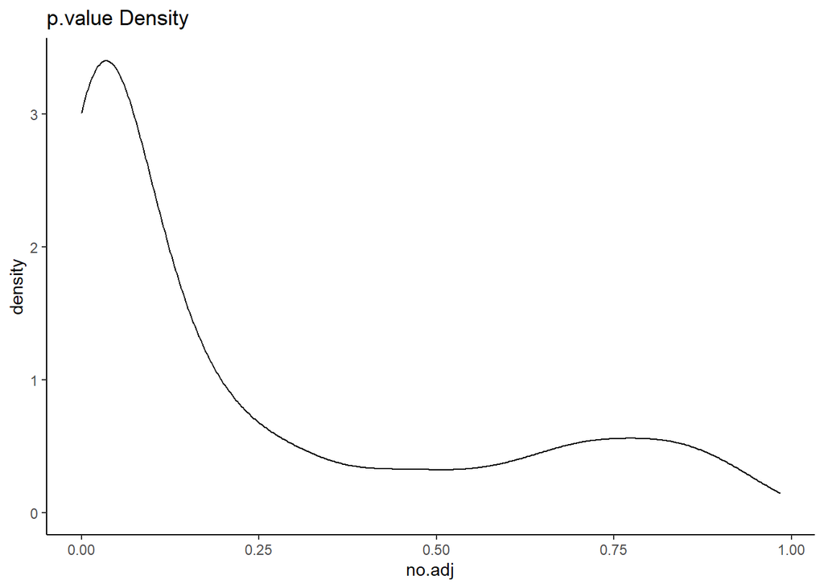

We have 1300 randomly generated p-values skewed towards the lower end of the p-value scale. There is also a small hump around *α* ≈ 0.75. Now let’s see what happens with the Bonferroni adjusted p-values:

```r
#perform bonferroni p-value adjustment
bon.p <- p.adjust(no.adj, method="bonferroni")

#summary statistics
summary(bon.p)
```

```
##     Min.  1st Qu.   Median     Mean  3rd Qu.     Max.
## 0.000082 1.000000 1.000000 0.971226 1.000000 1.000000
```

```r
#smallest p values
head(bon.p)
```

```
## [1] 8.203177e-05 4.676431e-04 2.275277e-03 5.263303e-03 7.179445e-03
## [6] 9.082152e-03
```

```r
#largest p values
tail(bon.p)
```

```
## [1] 1 1 1 1 1 1
```

```r
#average number of significant p-values/1300 from 100 trials of 1300
bon <- matrix(NA, nrow=100, ncol=1)
for (i in 1:100){
  beta[i,] <- p.adjust(beta[i,], method="bonferroni")
  bon[i,] <- length(which(beta[i,] <=0.05))
}
mean(bon)
```

```
## [1] 14.83
```

```r
#average number of ~1.0 p-values/1300 from 100 trials of 1300
for (i in 1:100){
  bon[i,] <- length(which(beta[i,] >=0.999))
}
mean(bon)
```

```
## [1] 1232.03
```

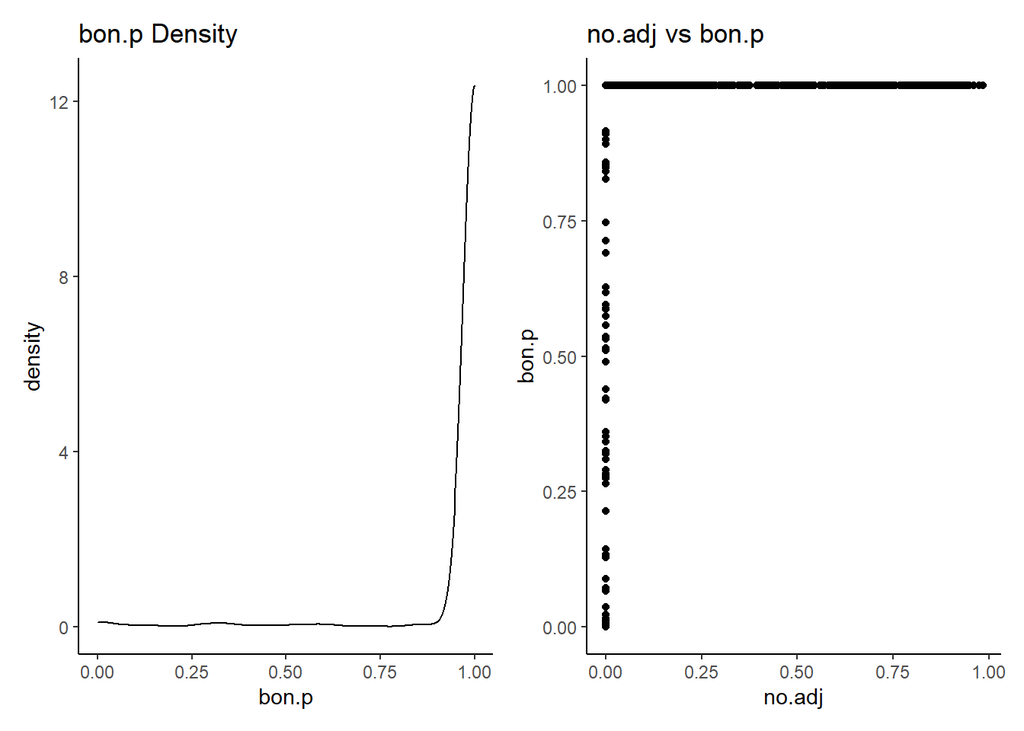

After the Bonferroni adjustment, there are much fewer values below the significance cut-off. Importantly, most of the p-values are now 1.0. This is clearly a misrepresentation of the overall structure of the data. However, the Bonferroni method can be valuable for identifying true positives with great certainty.

### The Benjamini-Hochberg Method

This method is philosophically different and more powerful than the Bonferroni method. Rather than controlling the false positive rate, the Benjamini-Hochberg method controls the false discovery rate. This is defined as the proportion of false positives among all significant results. P-values are ranked in an ascending array and multiplied by *m*/*k* where *k* is the position of a p-value in ascending order and *m* is the number of independent tests.

*α* = *α* * *m*/*k*

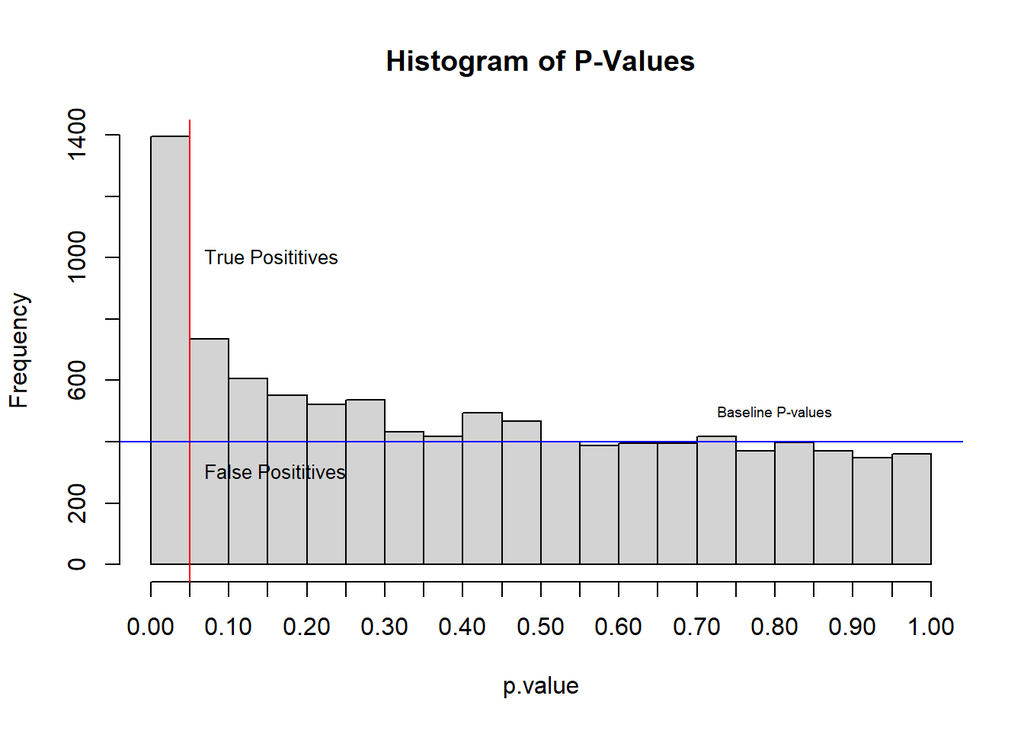

Below is an illustration of how this adjustment performs using the same data set as with the Bonferroni adjustment.

```r
#perform benjamini-hochberg p-value adjustment
bh.p <- p.adjust(no.adj, method="fdr")
#summary statistics
summary(bh.p)
```

```
##     Min.  1st Qu.   Median     Mean  3rd Qu.     Max.
## 0.000082 0.075564 0.182278 0.311249 0.507687 0.983829
```

```r
#smallest p values
head(bh.p)
```

```
## [1] 8.203177e-05 2.338215e-04 7.584255e-04 1.315826e-03 1.435889e-03
## [6] 1.513692e-03
```

```r
#largest p values
tail(bh.p)
```

```
## [1] 0.9504545 0.9510539 0.9514864 0.9631435 0.9751057 0.9838292
```

```r
#average number of significant p-values/1300 from 100 trials of 1300
bh <- matrix(NA, nrow=100, ncol=1)
for (i in 1:100){
  beta[i,] <- sort(c(rbeta(1000,.5,5),rbeta(300,5,2)))
  beta[i,] <- p.adjust(beta[i,], method="fdr")
  bh[i,] <- length(which(beta[i,] <=0.05))
}
mean(bh)
```

```
## [1] 228.56
```

```r
#average number of ~1.0 p-values/1300 from 100 trials of 1300
for (i in 1:100){
  bh[i,] <- length(which(beta[i,] >=0.999))
}
mean(bh)
```

```
## [1] 0
```

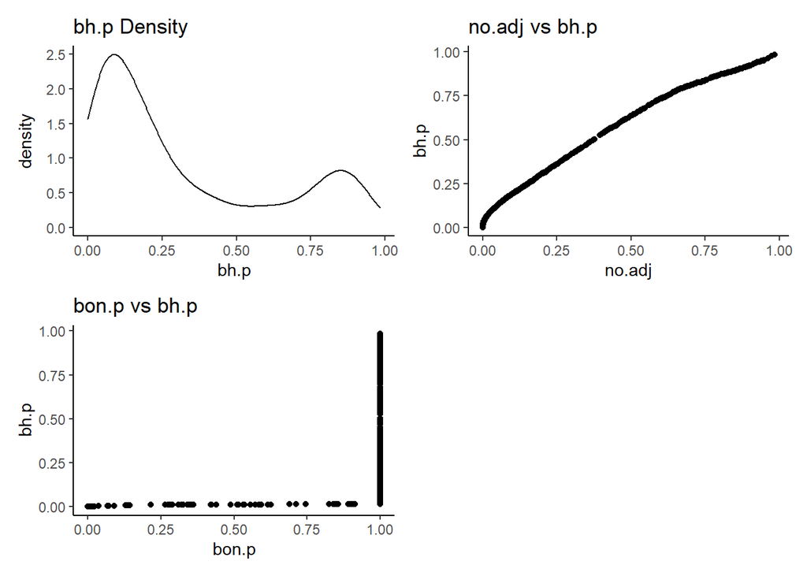

From this example, it is clear that the Benjamini-Hochberg adjustment has shifted the p-values from our distribution, but has not fundamentally changed the structure of the distribution. There are still a large number of significant p-values, while there are no 1.0s.

This more balanced approach is more appropriate for multiple testing correction in the context of ’omics data.